# Analysis of Recipes of Dutch Healthy Food Influencers

Wouter van elteren

2022-08-01

# Analysis of Recipes of Dutch Healthy Food Influencers on Instagram

As part of my bachelor thesis, I analysed the recipes promoted by Dutch Healthy Food Influencers on Instagram. Healthy food influencers (i.e. social media influencers that whose main content is healthy food) have seen a sharp rise in popularity due to the corona pandemic and “healthy lifestyle” trend. However, Dutch nutritionists are concerned about the influence healthy food influencers may have on their audience’s meal choice and may even be forming a risk to public health (Diëtisten verontust, 2021). They state that most Dutch healthy food influencers started as hobby cooks and are not certified dieticians or nutritionists and therefore should not be in a position to advise on healthy eating. This begs the question: how healthy are their recipes?

Additionally, my thesis examined the effect of the healthiness of a recipe on the amount of social media engagement (in the form of likes and comments) it received.

## Data Collection

### Healthy Food Influencer Sample

Healthy food influencers were selected by monitoring the “Top Posts” section of the “#gezondenrecpten” and “#gezondeten” hashtags on Instagram daily for a period of one month. Those who made the top posts section more than three times during that month were selected. This resulted in a sample of 19 healthy food influencers. The Instagram posts of each healthy food influencer of last month were subsequently examined. Influencers were removed if they did not provide an ingredient list for their recipes, since an ingredient list is required for the analysis, or if they were not of Dutch nationality. Additionally, an arbitrary threshold was set of 10.000 followers as a requirement for inclusion.

These exclusion criteria resulted in a final sample of 10 Dutch healthy food influencers. As an ethical consideration, the names of the healthy food influencer were made secret.

## Operationalising Variables

### Healthiness

The explanatory variable in this study’s design is the healthiness of a recipe depicted in a healthy food influencer’s Instagram post. The healthiness was determined via the NutriScore nutrient profile model. This model calculates a healthiness score (lower is healthier) for a recipe based on its calorie, saturated fat, sodium, otein, fibre, and vegetables, nuts, fruits content per 100g. In this study, the healthiness of a recipe is determined by the healthiness score. The NutriScore model gives meaning to the healthiness score by assigning a corresponding label named the NutriScore. The NutriScore goes from A (most healthy) to E (least healthy). The recommendations for the implementation of the NutriScore model state that public health initiatives should encourage the consumption of foods that receive a Nutri-Score of either A or B, while the consumption of foods that receive a Nutri-Score of D or E should be limited (Federale Overheidsdienst Volksgezondheid, Veiligheid van de Voedselketen en Leefmilieu, 2022).

The NutriScore is based on the following table:

| Healthiness Score | NutriScore |
| --- | --- |
| <-1 | A |
| 0 - 2 | B |
| 3 - 10 | C |
| 11 - 18 | D |
| >19 | E |

The meaning of the NutriScore finds itself in cancer research. A diet that mainly consist of food from a specific NutriScore has a corresponding increased risk of cancer. See the image below where Q1 corresponds to A, Q2 to B, … , Q5 to E

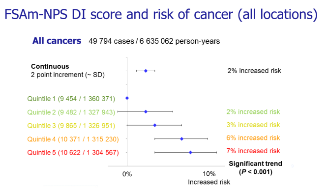

The NutriScore model was chosen for three reasons:

1. It is most relevant to the study, as NutriScore is adopted in the Netherlands and the sample consists of content from Dutch food influencers
2. Studies that compared European nutrient profiling models found NutriScore to be the most accurate for establishing objective healthiness
3. NutriScore translates to real-world effects (e.g. increased risk of cancer).

Both the healthiness score and NutriScore were obtained via the recipe_healthiness_analyser python program.

## Part 1: How Healthy are those Recipes?

### Load data and descriptive stats

```r
library(readr)

# Load recipes, drop unnecessary columns
recipes <- read_csv("analysed_recipes.csv", show_col_types = FALSE)
recipes <- recipes[-c(3, 4, 8:16)]

# Set variables
id <- recipes$id
author <- recipes$author
likes <- recipes$likes
comments <- recipes$comments
media <- recipes$media
healthiness_score <- recipes$healthiness_score
nutri_score <- recipes$nutri_score
```

```r
head(recipes)
```

```
## # A tibble: 6 × 7
##      id author media likes comments healthiness_score nutri_score
##   <dbl> <chr>  <chr> <dbl>    <dbl>             <dbl> <chr>
## 1  2554 HFI-1  video  1223       93                -1 A
## 2 27404 HFI-1  video   992      161                -7 A
## 3 21381 HFI-1  video  1367      220                 1 B
## 4 95444 HFI-1  video   873      103               -10 A
## 5 55461 HFI-1  video  1187      147                -5 A
## 6 56232 HFI-1  video  1582      151                 4 C
```

Let’s check the descriptive statistics

```r
summary(recipes)
```

```
##        id           author             media               likes           comments
##  Min.   :  337   Length:247         Length:247         Min.   :  87.0   Min.   :  5.00
##  1st Qu.:27239   Class :character   Class :character   1st Qu.: 282.5   1st Qu.: 40.00
##  Median :54075   Mode  :character   Mode  :character   Median : 461.0   Median : 72.00
##  Mean   :52752                                         Mean   : 708.5   Mean   : 86.17
##  3rd Qu.:78976                                         3rd Qu.:1032.0   3rd Qu.:120.00
##  Max.   :99843                                         Max.   :3078.0   Max.   :271.00
##  healthiness_score  nutri_score
##  Min.   :-10.0000   Length:247
##  1st Qu.: -5.0000   Class :character
##  Median : -2.0000   Mode  :character
##  Mean   : -0.8826
##  3rd Qu.:  1.0000
##  Max.   : 24.0000
```

Let’s also check for missing values, since no one should trust their own program’s :)

```r
colSums(is.na(recipes))
```

```
##                id            author             media             likes          comments
##                 0                 0                 0                 0                 0
## healthiness_score       nutri_score
##                 0                 0
```

Looks good.

Let’s see how many recipes each influencer has in the sample.

```r
library(dplyr)
recipes %>%
  group_by(author) %>%
  summarise(cnt = n())
```

```
## # A tibble: 10 × 2
##    author   cnt
##    <chr>  <int>
##  1 HFI-1     24
##  2 HFI-10    29
##  3 HFI-2     28
##  4 HFI-3     28
##  5 HFI-4     27
##  6 HFI-5     17
##  7 HFI-6     29
##  8 HFI-7     27
##  9 HFI-8     20
## 10 HFI-9     18
```

### Distribution of the healthiness Recipes

Let’s focus on the NutriScore for now. If we want to see how healthy the recipes are, and to what extent Dutch healthy food influencers contribute to increased cancer risk, we have to focus on its distribution.

```r
# NutriScore
library(dplyr)
recipes %>%
  group_by(nutri_score) %>%
  summarise(cnt = n()) %>%
  mutate(freq = round(cnt / sum(cnt), 3)) %>%
  arrange(desc(freq))
```

```
## # A tibble: 5 × 3
##   nutri_score   cnt  freq
##   <chr>       <int> <dbl>
## 1 A             160 0.648
## 2 B              40 0.162
## 3 C              31 0.126
## 4 D              12 0.049
## 5 E               4 0.016
```

Let’s see how the distribution per influencer is

```r
library(dplyr)
recipes %>%
  group_by(nutri_score, author) %>%
  summarise(cnt = n()) %>%
  mutate(freq = round(cnt / sum(cnt), 3)) %>%
  arrange(desc(freq))
```

```
## # A tibble: 36 × 4
## # Groups:   nutri_score [5]
##    nutri_score author   cnt  freq
##    <chr>       <chr>  <int> <dbl>
##  1 E           HFI-8      3 0.75
##  2 D           HFI-8      4 0.333
##  3 D           HFI-3      3 0.25
##  4 E           HFI-5      1 0.25
##  5 B           HFI-6      9 0.225
##  6 C           HFI-9      6 0.194
##  7 D           HFI-10     2 0.167
##  8 D           HFI-9      2 0.167
##  9 C           HFI-10     5 0.161
## 10 C           HFI-3      5 0.161
## # … with 26 more rows
```

Okay that may be a little hard to see. To better be able to judge the distribution of th healthiness of the recipes in our sample, lets visualise it

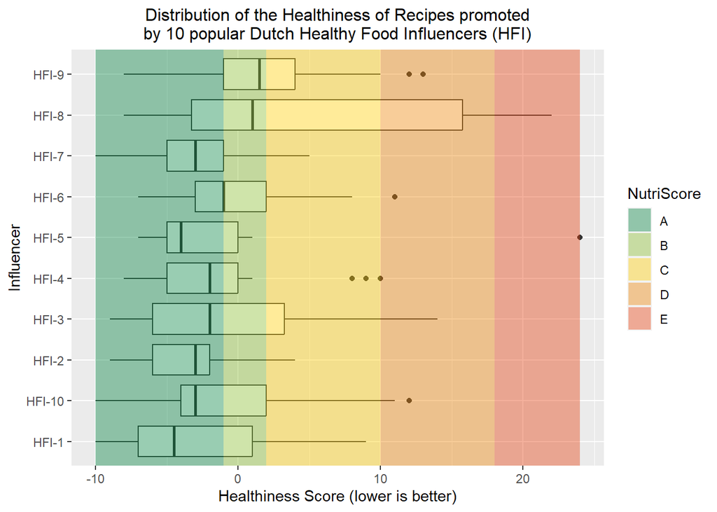

```r
library(ggplot2)

# colours of NutriScore
Ac <- "#00823F"
Bc <- "#86BC2B"
Cc <- "#FECC00"
Dc <- "#EE8200"
Ec <- "#E73C09"

nutri_colours <- c(Ac, Bc, Cc, Dc, Ec)

# Nutriscore bounds
lower_bounds <- c(-10, -1, 2, 10, 18)
upper_bounds <- c(-1, 2, 10, 18, 24)

# Rectangles that annotate the background of the plot
rects <- data.frame(
  start = lower_bounds,
  end = upper_bounds,
  fill = factor(1:5)
)

ggplot() +
  geom_boxplot(
    data = recipes,
    aes(x = author,
        y = healthiness_score)
  ) +
  geom_rect(
    data = rects,
    aes(ymin = start,
        ymax = end,
        fill = fill),
    xmin = -Inf,
    xmax = Inf,
    alpha = 0.4
  ) +
  scale_fill_manual(
    name = "NutriScore",
    labels = c("A", "B", "C", "D", "E"),
    values = nutri_colours
  ) +
  labs(
    x = "Influencer",
    y = "Healthiness Score (lower is better)"
  ) +
  ggtitle("Distribution of the Healthiness of Recipes promoted\nby 10 popular Dutch Healthy Food Influencers (HFI)") +
  theme(plot.title = element_text(size=12, hjust=0.5)) +
  coord_flip()
```

**Key takeaways:**

- It seems there is quite the spread in the healthiness of the recipes promoted, depending on the influencer. Definitely not all recipes are healthy!
- HFI-8 and maybe HFI-9 may actually not be healthy food influencers given their recipes’ healthiness. They may be leeching off the #gezonderecepten hashtag to reach a bigger audience.
- There are recipes that have a healthiness score considered as an probable outlier. This can either be due to a measurement error of recipe_healthiness_analyser or they are simple recipes for “cheat days”.
- Especially one recipe from HFI-5 has an healthiness score so extremely unhealthy that it is probably due to a measurement error.

Let’s first take a good look at the probable outliers. Let’s look at their origin and deal with them accordingly.

```r
# Retrieve outlier values and the author they belong ot
temp <- boxplot(healthiness_score ~ author, data = recipes, plot=FALSE)

#temp$out
#temp$group

# create vector based on temp$group
outlier_groups <- c("HFI-10", "HFI-4", "HFI-4","HFI-4","HFI-4", "HFI-5", "HFI-6", "HFI-9", "HFI-9")

# Retrieve the matches
keys <- data.frame(healthiness_score = temp$out, author = outlier_groups)
outlier_recipes <- merge(recipes, keys) %>% distinct()

outlier_recipes
```

```
##   author healthiness_score    id   media likes comments nutri_score
## 1 HFI-10                12 60760 picture   898       55           D
## 2  HFI-4                10 63689   video   591       34           C
## 3  HFI-4                 8 16683   video   241       23           C
## 4  HFI-4                 9  8524   video   368       42           C
## 5  HFI-4                 9 90316   video   415       32           C
## 6  HFI-5                24 78450 picture   371       27           E
## 7  HFI-6                11 83671   video   325       86           D
## 8  HFI-9                12 61393   video  1277       88           D
## 9  HFI-9                13 31333 picture   390       24           D
```

When looking up the id in the main dataset and the corresponding ingredient list of the recipe, it can be reasonably concluded that these are cheat meals instead of measurement errors. I think the best example to show to support this conclusion is the ingredient list of the one recipe of HFI-5 with the extreme healthiness score:

- 200 grams of MonChou
- 250 ml whipped cream
- 100 grams of white caster sugar
- 2 sachets of vanilla sugar
- 1 pack of bastogne biscuit
- 100 grams of butter

Yes, definitely not a recipe you would expect from a healthy food influencer.

In any case, looking at the distribution visualization, there is quite a spread in the healthiness of the recipes per influencer. Let’s quickly test if that difference is significant just to be sure.

```r
summary(aov(healthiness_score ~ author, data = recipes))
```

```
##              Df Sum Sq Mean Sq F value   Pr(>F)
## author        9   1385  153.94   4.621 1.22e-05 ***
## Residuals   237   7896   33.32
## ---
## Signif. codes:  0 '***' 0.001 '**' 0.01 '*' 0.05 '.' 0.1 ' ' 1
```

As previously mentioned, having a diet of mainly food belonging to a certain NutriScore has real-world implications on the probability of receiving cancer. Therefore, it may be more beneficial to focus on **what diet these healthy food influencers are promoting.** Consequently, we can calculate the mean healthiness score of their recipes, and assign a NutriScore to that. This way, we can understand how healthy, on average, their recipes are.

```r
# Get the mean healthiness score of recipe content per influencer
healthiness_score_inf.mean <- recipes %>%
  group_by(author) %>%
  summarise_at(vars(healthiness_score), list(mean = mean))

# round that healthiness score
healthiness_score_inf.mean$mean <- round(healthiness_score_inf.mean$mean, 1)

# Assign a NutriScore to it
healthiness_score_inf.mean <- healthiness_score_inf.mean %>%
    mutate(nutri_score_label = case_when(
      (between(mean, -10, -1)) ~ "A",
      (between(mean, -1, 2)) ~ "B",
      (between(mean, 2, 10)) ~ "C")
    )

healthiness_score_inf.mean
```

```
## # A tibble: 10 × 3
##    author  mean nutri_score_label
##    <chr>  <dbl> <chr>
##  1 HFI-1   -2.8 A
##  2 HFI-10  -0.6 B
##  3 HFI-2   -3.5 A
##  4 HFI-3   -0.4 B
##  5 HFI-4   -1.5 A
##  6 HFI-5   -1.9 A
##  7 HFI-6   -0.2 B
##  8 HFI-7   -3.3 A
##  9 HFI-8    5.2 C
## 10 HFI-9    2.1 C
```

Let’s visualise that!

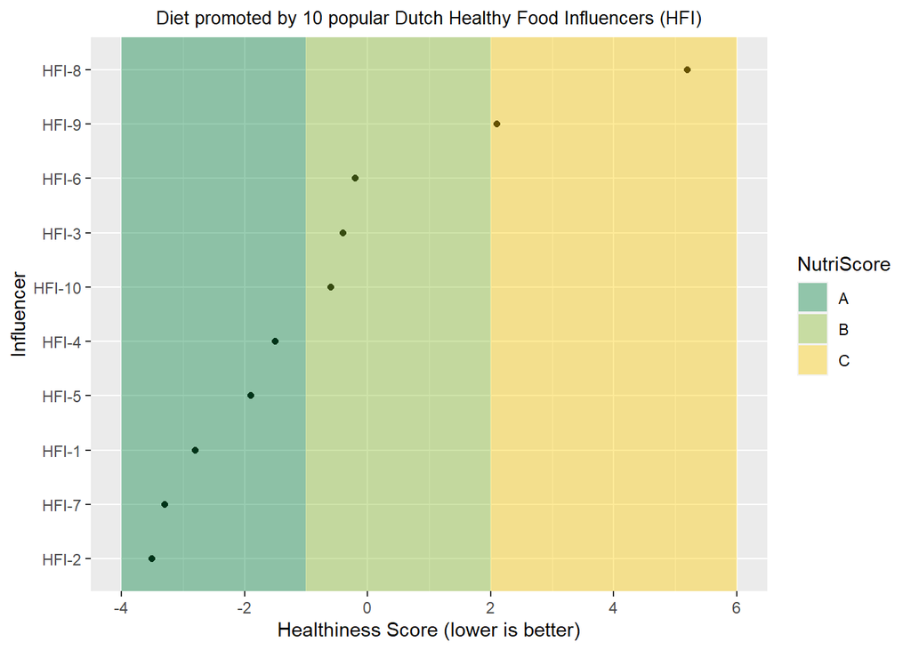

```r
nutri_colours2 <- c(Ac, Bc, Cc)

# Nutriscore bounds (cap at 6 instead of 10 to shorten x-axis)
lower_bounds2 <- c(-4, -1, 2)
upper_bounds2 <- c(-1, 2, 6)

# Rectangles that annotate the background of the plot
rects <- data.frame(
  start = lower_bounds2,
  end = upper_bounds2,
  fill = factor(1:3)
)

ggplot() +
  geom_point(
    data = healthiness_score_inf.mean,
    aes(x = reorder(author, mean),
        y = mean)
  ) +
  geom_rect(
    data = rects,
    aes(ymin = start,
        ymax = end,
        fill = fill),
    xmin = -Inf,
    xmax = Inf,
    alpha = 0.4
  ) +
  scale_fill_manual(
    name = "NutriScore",
    labels = c("A", "B", "C"),
    values = nutri_colours2
  ) +
  labs(
    x = "Influencer",
    y = "Healthiness Score (lower is better)"
  ) +
  ggtitle("Diet promoted by 10 popular Dutch Healthy Food Influencers (HFI)") +
  theme(plot.title = element_text(size=10, hjust=0.5)) +
  coord_flip()
```

Going by the recommendations of Federale Overheidsdienst Volksgezondheid, Veiligheid van de Voedselketen en Leefmilieu, two (supposed) Healthy Food Influencers, HFI-8 and HFI-9, would be promoting a diet that cannot be labeled as healthy.

### Conclusion

The concerns of Dutch nutritionists are warranted. Some self-oclaimed healthy food influencers fail to promote a healthy diet, and can therefore be considered a public-health risk. In the event a public entity, NGO or company would like to leverage healthy food influencers as instruments for public health initiatives, they should carefully consider the healthiness of the recipe content they are promoting.

## Part 2: Influence of Healthiness of recipes on Social media engagement

Contemporary literature suggest that unhealthy food receives more social media engagement (in the form of likes and comments). It therefore may be interesting, given the significant spread in recipe healthiness for some influencers, to see if the same holds true for our sample.

### Data exploration

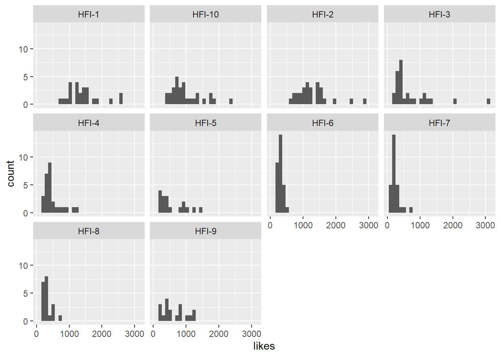

```r
# Histogram likes per influencer
ggplot() +
  geom_histogram(data = recipes, aes(x = likes)) +
  facet_wrap(~ author)
```

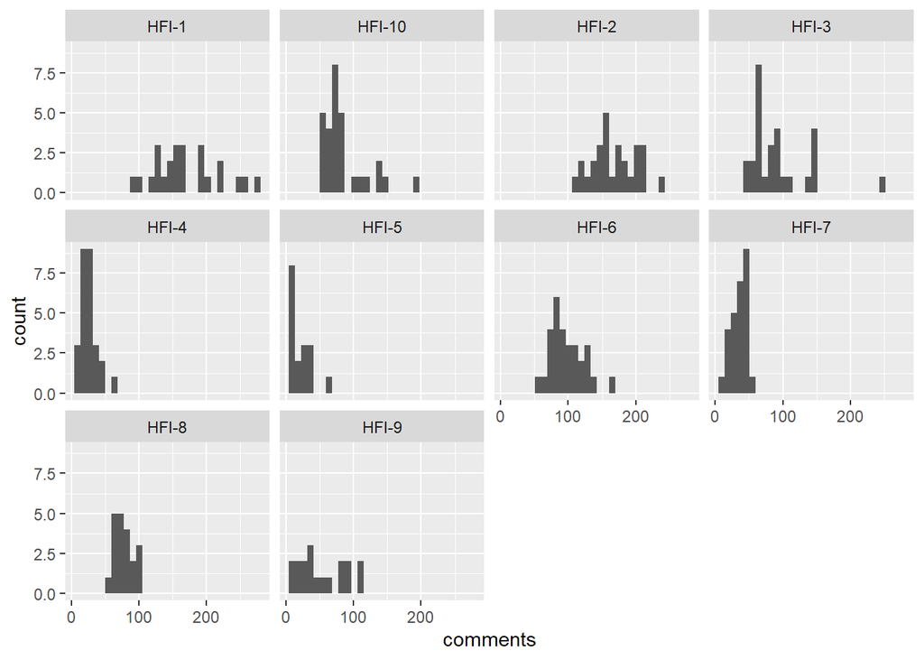

```r
# Histogram comments per influencer
ggplot() +
  geom_histogram(data = recipes, aes(x = comments)) +
  facet_wrap(~ author)
```

There are some problems here. Basically, there are many different reasons to like or comment on a instagram posts, and some of these reasons are also very dependent on instagram’s algorithm (e.g., if they show you a certain post or not). The sample per influencer is far too small to account for all those different reasons, hence the distributions that are plotted.

To still explore the effect of healthiness of likes and comments, we assume the analytical framework in my thesis holds true. Basically, this assumption holds that humans can generally accurately spot the difference in healthiness of recipes due to the evolutionary advances in our brain, even when the healthiness of recipes only differs slightly. Given this assumption, we can test for influence of healthiness of recipes on social media engagement for all influencers, no matter how much their recipe content varies in healthiness.

By doing so, we can do a mixed-effect model in order to explore that influence and still keep the entire sample size.

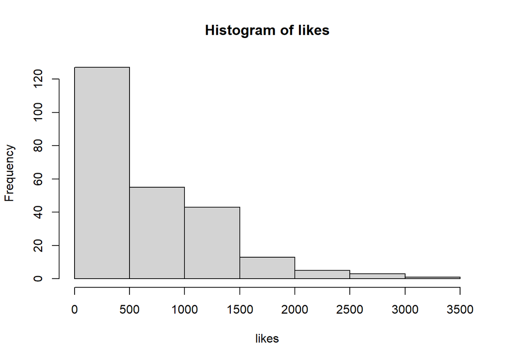

```r
hist(likes)
```

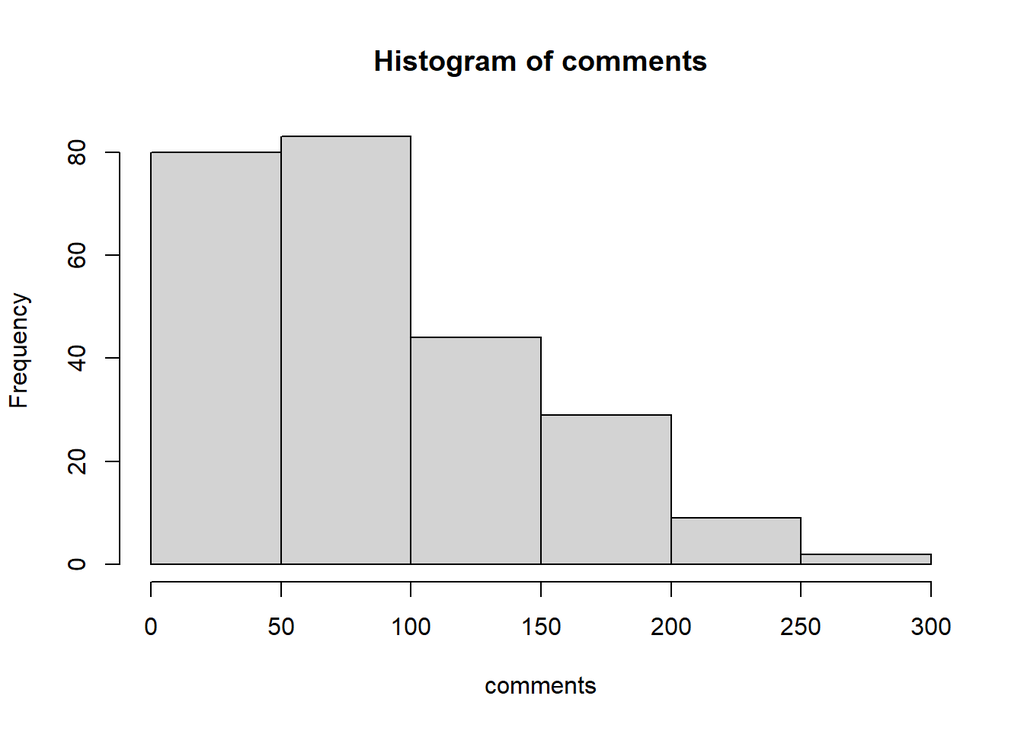

```r
hist(comments)
```

Definitely have to transform these.

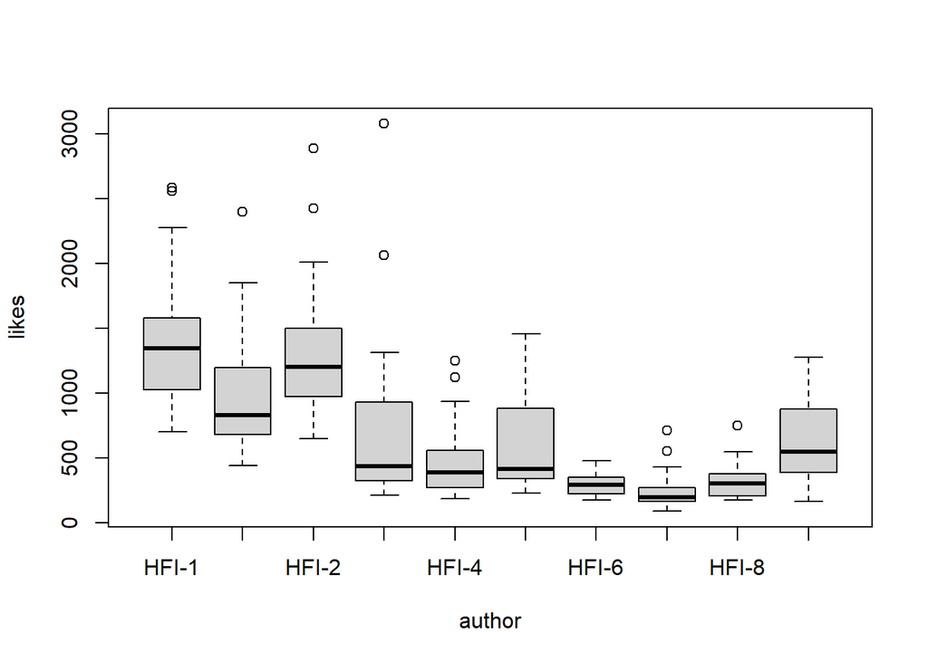

```
## [1] 12
```

```r
length(boxplot(likes ~ author)$out)
```

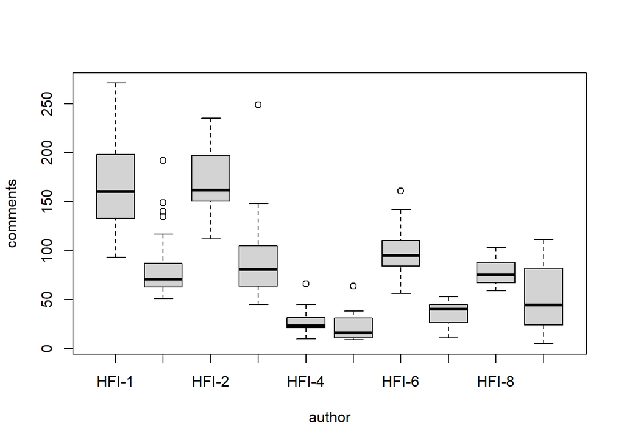

```
## [1] 8
```

```r
length(boxplot(comments ~ author)$out)
```

There are some notable outliers here. Instead of deleting those, and further reducing our already limited sample size, we keep them in. If they are also highly influential, we might run a robust mixed effect model instead.

### Data Transformation

```r
library(moments)
# check skewness
skewness(likes)
```

```
## [1] 1.463939
```

```r
skewness(comments)
```

```
## [1] 0.8437921
```

```r
# Transfrom
likes_log <- log10(likes)
comments_sqrt <- sqrt(comments)

skewness(likes_log)
```

```
## [1] 0.1515221
```

```r
skewness(comments_sqrt)
```

```
## [1] 0.1741327
```

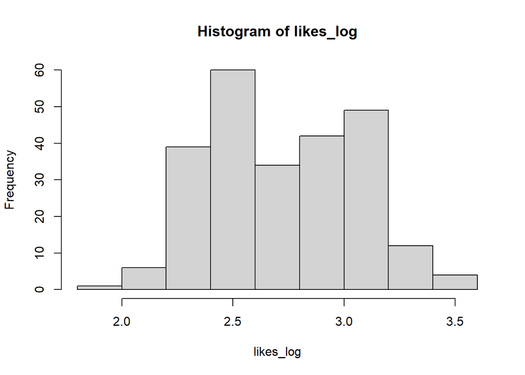

```r
# Visualise
hist(likes_log)
```

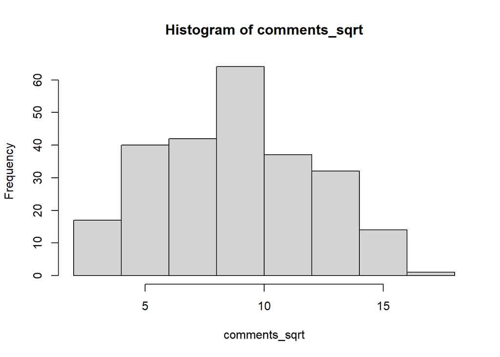

```r
hist(comments_sqrt)
```

Looks much better, although likes is still not normally distributed. Nevertheless, for mixed-effect models, only the residuals have to be normally distributed, so this is not a problem.

### Mixed-Effect Model

The lmerTest package is used for fitting mixed-effect models since it spits out p-values via Satterthwaite’s approximation method, which is superior to likelihood ratio tests for small sample sizes.

```r
library(lmerTest)

# First models
likes.lmm <- lmer(likes_log ~ healthiness_score + (1|author), data = recipes)
comments.lmm <- lmer(comments_sqrt ~ healthiness_score + (1|author), data = recipes)
```

```r
summary(likes.lmm)
```

```
## Linear mixed model fit by REML. t-tests use Satterthwaite's method ['lmerModLmerTest']
## Formula: likes_log ~ healthiness_score + (1 | author)
##    Data: recipes
##
## REML criterion at convergence: -27.9
##
## Scaled residuals:
##     Min      1Q  Median      3Q     Max
## -2.4878 -0.6639 -0.0979  0.5454  3.6200
##
## Random effects:
##  Groups   Name        Variance Std.Dev.
##  author   (Intercept) 0.07091  0.2663
##  Residual             0.04296  0.2073
## Number of obs: 247, groups:  author, 10
##
## Fixed effects:
##                    Estimate Std. Error        df t value Pr(>|t|)
## (Intercept)       2.721e+00  8.529e-02 9.032e+00  31.908 1.35e-10 ***
## healthiness_score 1.409e-04  2.327e-03 2.381e+02   0.061    0.952
## ---
## Signif. codes:  0 '***' 0.001 '**' 0.01 '*' 0.05 '.' 0.1 ' ' 1
##
## Correlation of Fixed Effects:
##             (Intr)
## hlthnss_scr 0.019
```

```r
summary(comments.lmm)
```

```
## Linear mixed model fit by REML. t-tests use Satterthwaite's method ['lmerModLmerTest']
## Formula: comments_sqrt ~ healthiness_score + (1 | author)
##    Data: recipes
##
## REML criterion at convergence: 959.4
##
## Scaled residuals:
##     Min      1Q  Median      3Q     Max
## -3.0179 -0.7016 -0.1327  0.6372  4.0520
##
## Random effects:
##  Groups   Name        Variance Std.Dev.
##  author   (Intercept) 8.768    2.961
##  Residual             2.347    1.532
## Number of obs: 247, groups:  author, 10
##
## Fixed effects:
##                    Estimate Std. Error        df t value Pr(>|t|)
## (Intercept)         8.54329    0.94168   8.99843   9.072 8.01e-06 ***
## healthiness_score   0.01503    0.01722 236.98043   0.873    0.384
## ---
## Signif. codes:  0 '***' 0.001 '**' 0.01 '*' 0.05 '.' 0.1 ' ' 1
##
## Correlation of Fixed Effects:
##             (Intr)
## hlthnss_scr 0.013
```

For both, p is higher than 0.05. Although the usage of p-values for mixed effect model selection is heavily debated, it paints a clear picture here that there is no association between healthiness score and likes and comments.

Let’s check the assumptions:

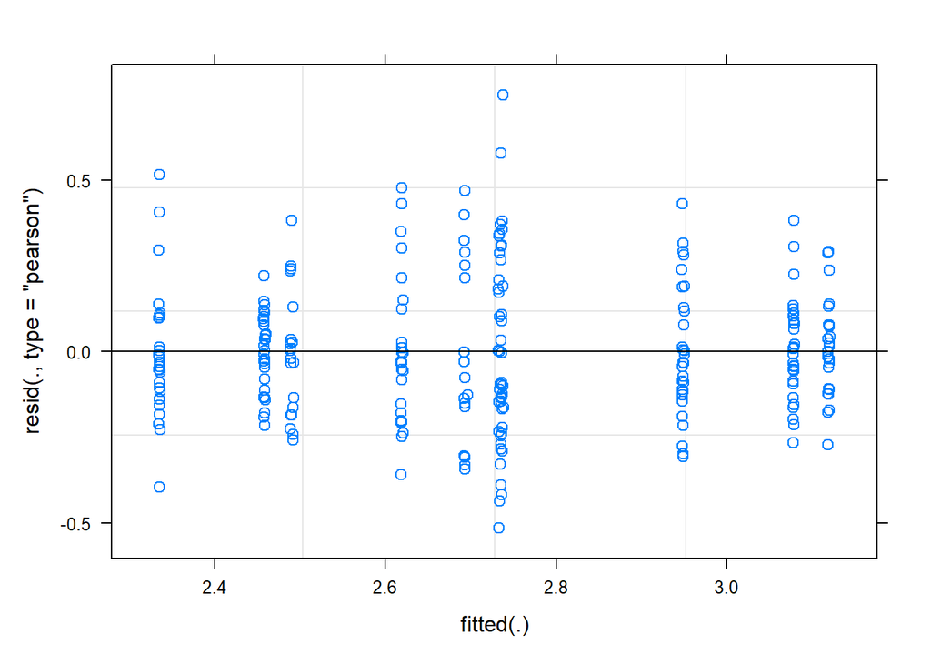

```r
plot(likes.lmm)
```

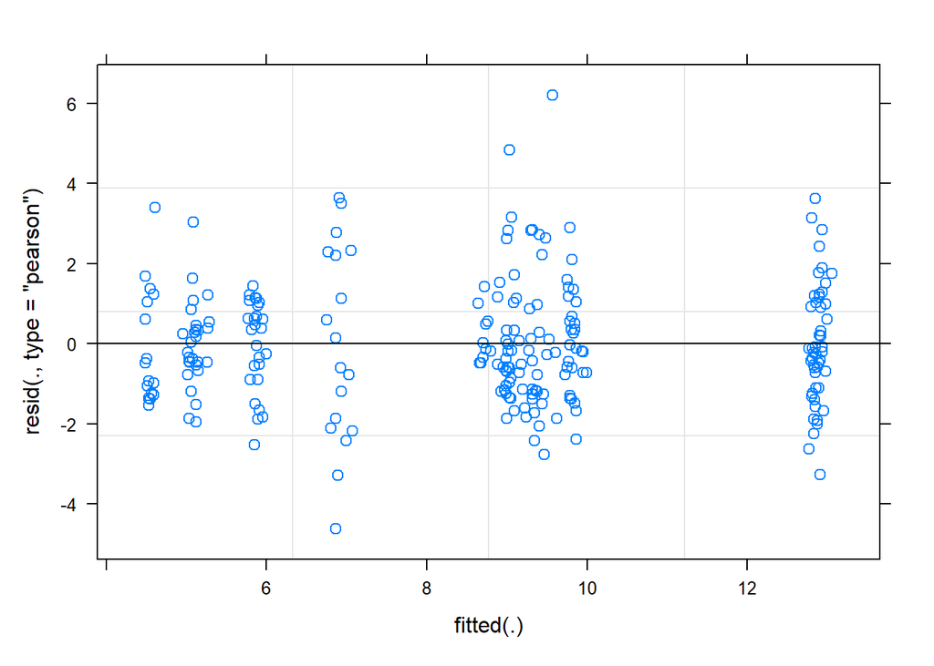

```r
plot(comments.lmm)
```

There are no patterns visible, so that’s good

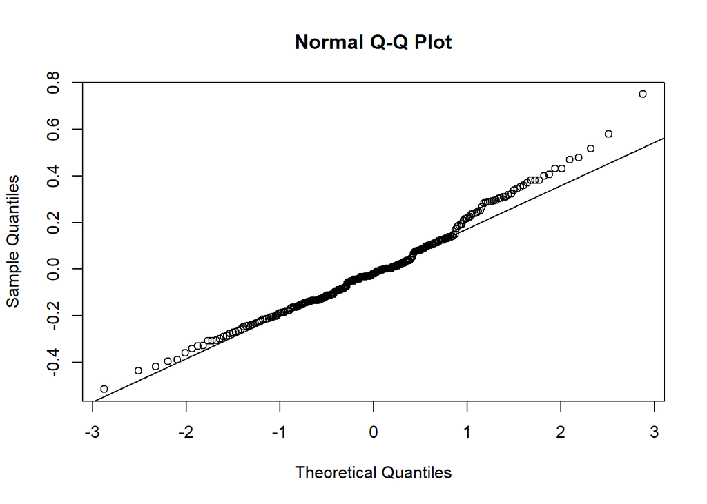

```r
qqnorm(resid(likes.lmm))
qqline(resid(likes.lmm))
```

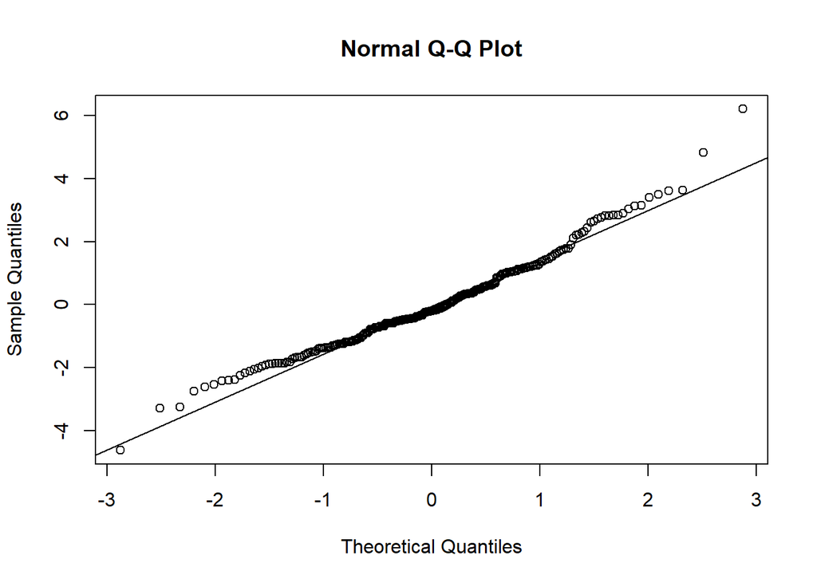

```r
qqnorm(resid(comments.lmm))
qqline(resid(comments.lmm))
```

Tails do not look that clean, but it’s okay’ish. A robust-lmm model may be beneficial though.

```r
library(robustlmm)

likes.rlmer <- rlmer(likes_log ~ healthiness_score + (1|author), data = recipes)
comments.rlmer <- rlmer(comments_sqrt ~ healthiness_score + (1|author), data = recipes)
```

```r
library(sjPlot)
library(sjtable2df)

likes.rlmer.tab <- tab_model(likes.rlmer)
sjtable2df::mtab2df(likes.rlmer.tab, n_models=1, output = "data.frame")
```

```
##                     Predictors     Estimates           CI      p
## 1                  (Intercept)          2.71  2.51 – 2.91 <0.001
## 2            healthiness score         -0.00 -0.00 – 0.00  0.847
## 3               Random Effects
## 4                           σ2          0.04
## 5                    τ00author          0.09
## 6                          ICC          0.70
## 7                     N author            10
## 8                 Observations           247
## 9 Marginal R2 / Conditional R2 0.000 / 0.700
```

```r
comments.rlmer.tab <- tab_model(comments.rlmer)
sjtable2df::mtab2df(comments.rlmer.tab, n_models=1, output = "data.frame")
```

```
##                     Predictors     Estimates           CI      p
## 1                  (Intercept)          8.43 6.29 – 10.58 <0.001
## 2            healthiness score          0.01 -0.02 – 0.04  0.553
## 3               Random Effects
## 4                           σ2          2.01
## 5                    τ00author         11.31
## 6                          ICC          0.85
## 7                     N author            10
## 8                 Observations           247
## 9 Marginal R2 / Conditional R2 0.000 / 0.849
```

We could expand our model: making it more complex by accounting for the effect of the media type of the recipe post (video or media), but that would most likely be beating a dead horse, given the output of the current models.

### Conclusion

No association could be found between the healthiness of a recipe and the amount of social media engagement it would receive. Our sample size is most likely too small to explore this interaction. Therefore, drawing any other conclusions from these findings will not be possible.